# MDSA Pre-Interview Question Answers (Data Visualization)

### Marc Anthony B Reyes

Growth Data Analyst Applicant | hello@marcreyes.ph | (+63)9129152323

- Which of the following statements is/are true from the chart?
- Fix the intentionally bad slide
- Which of the following statements is/are true?

**Legend**: **[x]** Selected answer

##### 1. Which of the following statements is/are true from the chart?

[figure not shown]

| Option | Description |
| --- | --- |
| **A** | The species Setosa has a mean Sepal Width that is less than its median Sepal Width. |
| **B** | If you take a random flower with Sepal Width of 3, there is a higher chance that it comes from the Virginica species compared to the Versicolor species |
| **[x] C** | **Both A and B are true** |
| **D** | Neither A or B is true |

##### 2. Fix the intentionally bad slide

[figure not shown]

Things that are wrong in the visualizations:

- **Size of the graphs**
  - The size of the graphs are quite small and the combination is disorganized. In addition, the viewer is confused as to where he/she should start reading. In order to make the visualization readable and organized, each visualization be placed on one (1) slide (in total, there will be three (3) of them).
- **On "The Mobile Wallet Share Ranking"**
  - The numbers just in front of the stacked bar graph are misleading and could mean other things. To accentuate its purpose, that is to show the composition of the market share every year, we can replace these labels into percentages.
  - The title of the graph is inconsistent and irrelevant to the visualization. It says Mobile Wallet Share Ranking, and it does not show, in any way on the graph, that there is ranking involved. We can correct this by separating each year in different graphs and show which share in a year has a higher and lower rank.
- **On "Google Play Store Ratings"**
  - The title clearly shows ratings of each indvidual mobile app, and therefore the graph shouldn't be visualized as a pie chart as the individual ratings are not part or a composition of an entity which could be visualized as percentages or divisions in a pie chart. Instead, we can change this into five-star type of visualization or a bar graph where we will show which app has the highest or lowest rating out of five (5).
- **On "Monthly Active Users in the Mobile Wallet Market"**
  - Each bar on the chart are awkwardly incomplete which, when viewed, could mean other information to the viewer. To correct this, we should complete the bottom part of each bar to make it consistent and understandable.
  - There is one bar with a different color on the chart named Subtotal. We should remove this as there is no need to show subtotal in the chart.
  - We can change the chart type to a line chart to show how the value of the monthly users progress every month. The viewers more clearly could understand how values have increased/increased on all months. A positive slope in the line chart means an increase or growth while a negative slope in the line chart would mean a decline or decrease.

```python
# Libary imports
import warnings
import matplotlib.pyplot as plt
import numpy as n

from matplotlib import rcParams
rcParams['font.size'] = 15

warnings.filterwarnings("ignore")
plt.style.use('fivethirtyeight')
```

**Mobile Wallet Share Ranking**

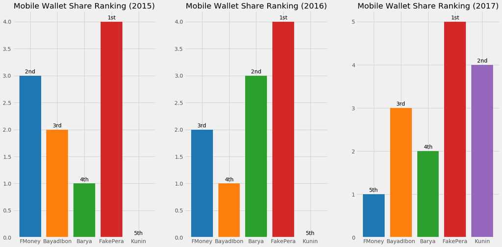

```python
# Mobile Wallet Share Ranking
f, (ax1, ax2, ax3) = plt.subplots(1, 3, sharey=False, figsize=(20, 10))

x = ['FMoney', 'BayadIbon', 'Barya', 'FakePera', 'Kunin']
y_2015 = [3, 2, 1, 4, 0]
y_2016 = [2, 1, 3, 4, 0]
y_2017 = [1, 3, 2, 5, 4]

ax1.bar(x, y_2015, color=['#1f77b4', '#ff7f0e', '#2ca02c', '#d62728', '#9467bd'])
ax1.set_title('Mobile Wallet Share Ranking (2015)')

for p in ax1.patches:
    y_2015_s = sorted(y_2015, reverse=True)
    g = y_2015_s.index(p.get_height())

    ordinal = lambda n: "%d%s" % (n,"tsnrhtdd"[(n/10%10!=1)*(n%10<4)*n%10::4])
    ordinal = [ordinal(n) for n in range(1,6)]

    g = ordinal[g]
    ax1.annotate(g,
                 (p.get_x()+p.get_width()/2., p.get_height()),
                 ha='center',
                 va='center',
                 xytext=(0, 10),
                 textcoords='offset points')

ax2.bar(x, y_2016, color=['#1f77b4', '#ff7f0e', '#2ca02c', '#d62728', '#9467bd'])
ax2.set_title('Mobile Wallet Share Ranking (2016)')

for p in ax2.patches:
    y_2016_s = sorted(y_2016, reverse=True)
    g = y_2016_s.index(p.get_height())

    ordinal = lambda n: "%d%s" % (n,"tsnrhtdd"[(n/10%10!=1)*(n%10<4)*n%10::4])
    ordinal = [ordinal(n) for n in range(1,6)]

    g = ordinal[g]
    ax2.annotate(g,
                 (p.get_x()+p.get_width()/2., p.get_height()),
                 ha='center',
                 va='center',
                 xytext=(0, 10),
                 textcoords='offset points')

ax3.bar(x, y_2017, color=['#1f77b4', '#ff7f0e', '#2ca02c', '#d62728', '#9467bd'])
ax3.set_title('Mobile Wallet Share Ranking (2017)')

for p in ax3.patches:
    y_2017_s = sorted(y_2017, reverse=True)
    g = y_2017_s.index(p.get_height())

    ordinal = lambda n: "%d%s" % (n,"tsnrhtdd"[(n/10%10!=1)*(n%10<4)*n%10::4])
    ordinal = [ordinal(n) for n in range(1,6)]

    g = ordinal[g]
    ax3.annotate(g,
                 (p.get_x()+p.get_width()/2., p.get_height()),
                 ha='center',
                 va='center',
                 xytext=(0, 10),
                 textcoords='offset points')
```

**Google Play Store Ratings**

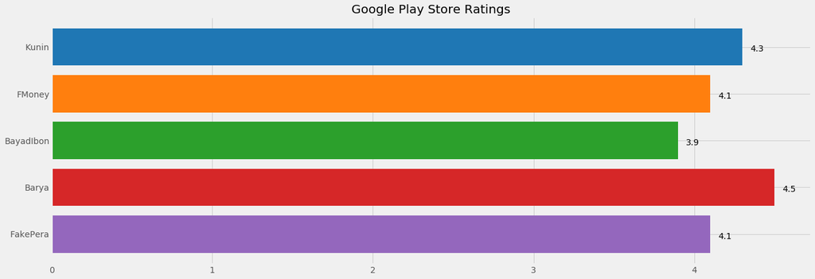

```python
# Google Play Store Ratings
x = ['Kunin', 'FMoney', 'BayadIbon', 'Barya', 'FakePera']
y = [4.3, 4.1, 3.9, 4.5, 4.1]

fig, ax = plt.subplots(figsize=(20, 7))

ax.barh(x, y, color=['#1f77b4', '#ff7f0e', '#2ca02c', '#d62728', '#9467bd'])
ax.invert_yaxis()
ax.set_title('Google Play Store Ratings')

for i, v in enumerate(y):
    ax.text(v+.05, i + .1, str(v))
```

**Monthly Active Users in the Mobile Wallet Market**

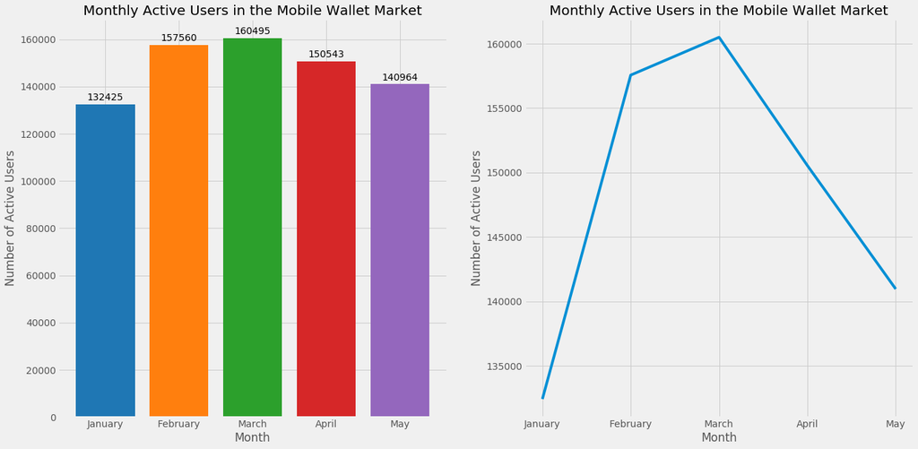

```python
# Monthly Active Users in the Mobile Wallet Market
f, (ax1, ax2) = plt.subplots(1, 2, sharey=False, figsize=(20, 10))

x = ['January', 'February', 'March', 'April', 'May']
y = [132425, 157560, 160495, 150543, 140964]

ax1.bar(x, y, color=['#1f77b4', '#ff7f0e', '#2ca02c', '#d62728', '#9467bd'])
ax1.set_title('Monthly Active Users in the Mobile Wallet Market')
ax1.set_xlabel('Month')
ax1.set_ylabel('Number of Active Users')

for p in ax1.patches:
    ax1.annotate(np.round(p.get_height(),decimals=2),
                 (p.get_x()+p.get_width()/2., p.get_height()),
                 ha='center',
                 va='center',
                 xytext=(0, 10),
                 textcoords='offset points')

ax2.plot(x, y)
ax2.set_title('Monthly Active Users in the Mobile Wallet Market')
ax2.set_xlabel('Month')
ax2.set_ylabel('Number of Active Users')
```

##### 3. The chart below represents a retention matrix which describes the percentage of people from the week of their first purchase that still continues to buy a certain product the following weeks after. (Acquisition week represents the week beginning Monday to Sunday). Which of the following statement(s) is/are true (all the time)?

[figure not shown]

[output not shown]